# STAT/CSSS 564: Assignment 4

Kirsten Wiens

May 23, 2017

```r
# load packages
library("rstan")
library("rstanarm")
library("haven")
library("tidyverse")
library("loo")
```

```r
# for faster sampling using Stan, avoids needless recompilation
rstan_options(auto_write = TRUE)
```

```r
# run Stan models in parallel if possible
options(mc.cores = parallel::detectCores())
```

```r
# variables we'll use later
keepvars <- c("ccode", "country", "year", "onset", "warl", "gdpenl", "lpopl1", "lmtnest", "ncontig",
"Oil", "nwstate", "instab", "polity2l", "ethfrac", "relfrac",
"anocl", "deml", "nwarsl", "plural", "plurrel", "muslim", "loglang",
"colfra", "eeurop", "lamerica", "ssafrica", "asia", "nafrme",
"second")

# original Fearon & Laitin war
fl <- read_dta('https://github.com/UW-CSSS-564/assignment-2017-4/blob/master/data/fl.dta?raw=true') %>%
# remove a coding error
  filter(onset != 4) %>%
  # add the count of wars in neighboring countries
  inner_join(read_dta("https://github.com/UW-CSSS-564/assignment-2017-4/raw/master/data/nwarsl.dta"), by = c("ccode", "year")) %>%
  # log(number of languages)
  mutate(loglang = log(numlang)) %>%
  select(one_of(keepvars))
```

# 1 Replicating Fearon and Laitin

Run the models:

```r
# run model 1 with predictor loglang
mod1 <- stan_glm(onset ~ loglang, family = binomial(), data = fl, prior_intercept = normal(0,10), prior = normal(0, 2.5), chains = 2, iter = 1000)

# run model 2 with predictors loglang and Oil
mod2 <- stan_glm(onset ~ loglang + Oil, family = binomial(), data = fl, prior_intercept = normal(0,10), prior = normal(0, 2.5), chains = 2, iter = 1000)
```

Show model summaries and compare the models using loo:

```r
# show summary of model 1
summary(mod1)
```

```
## stan_glm(formula = onset ~ loglang, family = binomial(), data = fl,
##     chains = 2, iter = 1000, prior = normal(0, 2.5), prior_intercept = normal(0,
##         10))
##
## Family: binomial (logit)
## Algorithm: sampling
## Posterior sample size: 1000
## Observations: 6609
##
## Estimates:
##                 mean   sd     2.5%   25%    50%    75%    97.5%
## (Intercept)     -4.6    0.2   -5.0   -4.8   -4.6   -4.5   -4.3
## loglang          0.3    0.1    0.2    0.3    0.3    0.4    0.5
## mean_PPD         0.0    0.0    0.0    0.0    0.0    0.0    0.0
## log-posterior -558.4    1.0 -560.9 -558.7 -558.1 -557.7 -557.4
##
## Diagnostics:
##               mcse Rhat n_eff
## (Intercept)   0.0  1.0  354
## loglang       0.0  1.0  411
## mean_PPD      0.0  1.0  966
## log-posterior 0.0  1.0  419
##
## For each parameter, mcse is Monte Carlo standard error, n_eff is a crude measure of effective sample size, and Rhat is the potential scale reduction factor on split chains (at convergence Rhat=1).
```

```r
# calculate loo for model 1
loo_mod1 <- loo(mod1)
loo_mod1
```

```
## Computed from 1000 by 6609 log-likelihood matrix
##
##          Estimate   SE
## elpd_loo   -555.2 42.2
## p_loo         2.2  0.2
## looic      1110.4 84.4
##
## All Pareto k estimates are good (k < 0.5)
## See help('pareto-k-diagnostic') for details.
```

```r
# show summary of model 2
summary(mod2)
```

```
## stan_glm(formula = onset ~ loglang + Oil, family = binomial(),
##     data = fl, chains = 2, iter = 1000, prior = normal(0, 2.5),
##     prior_intercept = normal(0, 10))
##
## Family: binomial (logit)
## Algorithm: sampling
## Posterior sample size: 1000
## Observations: 6609
##
## Estimates:
##                 mean   sd     2.5%   25%    50%    75%    97.5%
## (Intercept)     -4.7    0.2   -5.1   -4.9   -4.7   -4.6   -4.4
## loglang          0.4    0.1    0.2    0.3    0.4    0.4    0.6
## Oil              0.5    0.3    0.0    0.3    0.5    0.7    1.0
## mean_PPD         0.0    0.0    0.0    0.0    0.0    0.0    0.0
## log-posterior -558.0    1.2 -561.2 -558.5 -557.7 -557.1 -556.6
##
## Diagnostics:
##               mcse Rhat n_eff
## (Intercept)   0.0  1.0  787
## loglang       0.0  1.0  867
## Oil           0.0  1.0  691
## mean_PPD      0.0  1.0  880
## log-posterior 0.1  1.0  465
##
## For each parameter, mcse is Monte Carlo standard error, n_eff is a crude measure of effective sample size, and Rhat is the potential scale reduction factor on split chains (at convergence Rhat=1).
```

```r
# calculate loo for model 2
loo_mod2 <- loo(mod2)
loo_mod2
```

```
## Computed from 1000 by 6609 log-likelihood matrix
##
##          Estimate   SE
## elpd_loo   -554.4 42.2
## p_loo         3.3  0.4
## looic      1108.9 84.5
##
## All Pareto k estimates are good (k < 0.5)
## See help('pareto-k-diagnostic') for details.
```

```r
# compare the models using loo
compare(loo_mod1, loo_mod2)
```

```
## elpd_diff        se
##       0.8       1.9
```

# 2 Regularizing Priors

Run the models:

```r
# run model 3 with all variables and a weakly informative prior
# use preferred prior from previous question N(0, 2.5)
mod3 <- stan_glm(onset ~ warl + gdpenl + lpopl1 + lmtnest + ncontig + Oil + nwstate + instab + polity2l + ethfrac + relfrac + anocl + deml + nwarsl + plural + plurrel + muslim + loglang + colfra + eeurop + lamerica + ssafrica + asia + nafrme + second, family = binomial(), data = fl,  prior_intercept = normal(0,10), prior = normal(0, 2.5), chains = 2, iter = 1000)

# run model 4 with all variables and a hierarchical shrinkage prior
# use the prior hs(2, 0.02)
mod4 <- stan_glm(onset ~ warl + gdpenl + lpopl1 + lmtnest + ncontig + Oil + nwstate + instab + polity2l + ethfrac + relfrac + anocl + deml + nwarsl + plural + plurrel + muslim + loglang + colfra + eeurop + lamerica + ssafrica + asia + nafrme + second, family = binomial(), data = fl,  prior_intercept = normal(0,10), prior = hs(df = 2, global_scale = 0.02), adapt_delta = 0.6, chains = 2, iter = 1000)
```

Show model summaries indicating means and credible intervals:

```r
# show summary of model 3 (weak prior)
summary(mod3)
```

```
## stan_glm(formula = onset ~ warl + gdpenl + lpopl1 + lmtnest +
##     ncontig + Oil + nwstate + instab + polity2l + ethfrac + relfrac +
##     anocl + deml + nwarsl + plural + plurrel + muslim + loglang +
##     colfra + eeurop + lamerica + ssafrica + asia + nafrme + second,
##     family = binomial(), data = fl, chains = 2, iter = 1000,
##     prior = normal(0, 2.5), prior_intercept = normal(0, 10))
##
## Family: binomial (logit)
## Algorithm: sampling
## Posterior sample size: 1000
## Observations: 6326
##
## Estimates:
##                 mean   sd     2.5%   25%    50%    75%    97.5%
## (Intercept)     -9.1    2.7  -14.5  -10.9   -9.1   -7.4   -4.1
## warl            -0.9    0.3   -1.6   -1.1   -0.9   -0.7   -0.4
## gdpenl          -0.2    0.1   -0.4   -0.3   -0.2   -0.2   -0.1
## lpopl1           0.3    0.1    0.1    0.2    0.3    0.3    0.4
## lmtnest          0.2    0.1    0.0    0.1    0.2    0.3    0.4
## ncontig          0.5    0.3   -0.1    0.3    0.5    0.8    1.2
## Oil              0.6    0.3    0.0    0.4    0.6    0.9    1.2
## nwstate          1.6    0.4    0.9    1.4    1.6    1.9    2.3
## instab           0.5    0.2    0.0    0.3    0.5    0.7    1.0
## polity2l         0.1    0.0    0.0    0.0    0.1    0.1    0.2
## ethfrac          0.2    0.7   -1.2   -0.3    0.1    0.7    1.5
## relfrac          1.6    2.1   -2.7    0.1    1.6    3.0    5.4
## anocl            0.0    0.4   -0.8   -0.2    0.0    0.3    0.8
## deml            -0.9    0.7   -2.4   -1.3   -0.9   -0.4    0.6
## nwarsl           0.0    0.1   -0.2    0.0    0.0    0.1    0.2
## plural          -0.3    0.8   -1.8   -0.9   -0.3    0.3    1.2
## plurrel          0.0    0.0    0.0    0.0    0.0    0.0    0.1
## muslim           0.0    0.0    0.0    0.0    0.0    0.0    0.0
## loglang         -0.1    0.2   -0.5   -0.2   -0.1    0.0    0.3
## colfra          -0.2    0.3   -0.8   -0.4   -0.2    0.0    0.4
## eeurop           0.6    0.7   -0.7    0.1    0.6    1.1    2.0
## lamerica         1.1    0.7   -0.1    0.7    1.1    1.6    2.4
## ssafrica         1.5    0.7    0.2    1.0    1.6    2.1    2.9
## asia             1.2    0.6    0.1    0.8    1.2    1.7    2.4
## nafrme           1.4    0.7    0.0    0.9    1.4    1.9    2.7
## second          -1.2    1.5   -4.2   -2.1   -1.1   -0.1    1.5
```

[output cut: 20 more lines]

```
## plural        0.0  1.0  1000
## plurrel       0.0  1.0   603
## muslim        0.0  1.0  1000
## loglang       0.0  1.0   840
## colfra        0.0  1.0  1000
## eeurop        0.0  1.0   543
## lamerica      0.0  1.0   498
## ssafrica      0.0  1.0   434
## asia          0.0  1.0   499
## nafrme        0.0  1.0   539
## second        0.1  1.0   821
## mean_PPD      0.0  1.0  1000
## log-posterior 0.2  1.0   397
##
## For each parameter, mcse is Monte Carlo standard error, n_eff is a crude measure of effective sample size, and Rhat is the potential scale reduction factor on split chains (at convergence Rhat=1).
```

```r
# show summary of model 4 (shrinkage prior)
summary(mod4)
```

```
## stan_glm(formula = onset ~ warl + gdpenl + lpopl1 + lmtnest +
##     ncontig + Oil + nwstate + instab + polity2l + ethfrac + relfrac +
##     anocl + deml + nwarsl + plural + plurrel + muslim + loglang +
##     colfra + eeurop + lamerica + ssafrica + asia + nafrme + second,
##     family = binomial(), data = fl, chains = 2, iter = 1000,
##     prior = hs(df = 2, global_scale = 0.02), prior_intercept = normal(0,
##         10), adapt_delta = 0.6)
##
## Family: binomial (logit)
## Algorithm: sampling
## Posterior sample size: 1000
## Observations: 6326
##
## Estimates:
##                 mean   sd     2.5%   25%    50%    75%    97.5%
## (Intercept)     -6.1    1.0   -8.3   -6.7   -6.0   -5.4   -4.3
## warl            -0.3    0.3   -1.0   -0.6   -0.3   -0.1    0.0
## gdpenl          -0.3    0.1   -0.4   -0.3   -0.3   -0.2   -0.1
## lpopl1           0.2    0.1    0.1    0.2    0.2    0.3    0.4
## lmtnest          0.1    0.1    0.0    0.1    0.1    0.2    0.3
## ncontig          0.1    0.2   -0.1    0.0    0.1    0.2    0.6
## Oil              0.3    0.3   -0.1    0.0    0.2    0.4    1.0
## nwstate          1.3    0.5    0.2    1.1    1.4    1.6    2.1
## instab           0.2    0.2   -0.1    0.0    0.1    0.3    0.7
## polity2l         0.0    0.0    0.0    0.0    0.0    0.0    0.1
## ethfrac          0.0    0.2   -0.3   -0.1    0.0    0.1    0.5
## relfrac          0.1    0.4   -0.4    0.0    0.0    0.1    1.4
## anocl            0.3    0.3   -0.1    0.1    0.3    0.5    0.8
## deml            -0.2    0.3   -1.2   -0.3    0.0    0.0    0.2
## nwarsl           0.0    0.1   -0.1    0.0    0.0    0.1    0.2
## plural           0.0    0.2   -0.4   -0.1    0.0    0.0    0.3
## plurrel          0.0    0.0    0.0    0.0    0.0    0.0    0.0
## muslim           0.0    0.0    0.0    0.0    0.0    0.0    0.0
## loglang          0.0    0.1   -0.2    0.0    0.0    0.0    0.2
## colfra          -0.1    0.2   -0.4   -0.1    0.0    0.0    0.2
## eeurop          -0.1    0.2   -0.6   -0.1    0.0    0.0    0.2
## lamerica         0.0    0.2   -0.3    0.0    0.0    0.1    0.5
## ssafrica         0.0    0.2   -0.2    0.0    0.0    0.1    0.4
## asia             0.1    0.2   -0.2    0.0    0.0    0.1    0.5
## nafrme           0.0    0.2   -0.3    0.0    0.0    0.1    0.5
```

[output cut: 21 more lines]

```
## plural        0.0  1.0  528
## plurrel       0.0  1.0   84
## muslim        0.0  1.0  386
## loglang       0.0  1.0  484
## colfra        0.0  1.0  457
## eeurop        0.0  1.0  303
## lamerica      0.0  1.0  175
## ssafrica      0.0  1.0  542
## asia          0.0  1.0  479
## nafrme        0.0  1.0  276
## second        0.0  1.0  112
## mean_PPD      0.0  1.0  709
## log-posterior 0.8  1.0   97
##
## For each parameter, mcse is Monte Carlo standard error, n_eff is a crude measure of effective sample size, and Rhat is the potential scale reduction factor on split chains (at convergence Rhat=1).
```

- The coefficients are closer to 0, have lower standard deviations, and have narrower credible intervals for the model with the hierarchical shrinkage prior.
- Using the model with the weak prior, the coefficients with largest effects are (1) whether it is a new state and (2) the religious fractionalization. Using the model with the shrinkage prior the coefficient with largest effect is (1) whether it is a new state and the religious fraction has no effect (although, for both models the 95% credible interval for religious fractionalization crosses 0 so hard conclude anything).

# 3 Variable Scaling

Run a model with a weakly informative prior without variable scaling:

```r
# run model 3 with autoscale set to FALSE
mod5 <- stan_glm(onset ~ warl + gdpenl + lpopl1 + lmtnest + ncontig + Oil + nwstate + instab + polity2l + ethfrac + relfrac + anocl + deml + nwarsl + plural + plurrel + muslim + loglang + colfra + eeurop + lamerica + ssafrica + asia + nafrme + second, family = binomial(), data = fl,  prior_intercept = normal(0,1, autoscale = FALSE), prior = normal(0, 1, autoscale = FALSE), chains = 2, iter = 1000)
```

Show model summary:

```r
summary(mod5)
```

```
## stan_glm(formula = onset ~ warl + gdpenl + lpopl1 + lmtnest +
##     ncontig + Oil + nwstate + instab + polity2l + ethfrac + relfrac +
##     anocl + deml + nwarsl + plural + plurrel + muslim + loglang +
##     colfra + eeurop + lamerica + ssafrica + asia + nafrme + second,
##     family = binomial(), data = fl, chains = 2, iter = 1000,
##     prior = normal(0, 1, autoscale = FALSE), prior_intercept = normal(0,
##         1, autoscale = FALSE))
##
## Family: binomial (logit)
## Algorithm: sampling
## Posterior sample size: 1000
## Observations: 6326
##
## Estimates:
##                 mean     sd       2.5%     25%      50%      75%
## (Intercept)      -21.1     14.3    -35.4    -35.4    -23.5     -6.8
## warl              -1.3      0.5     -1.8     -1.8     -1.7     -0.8
## gdpenl             0.4      0.7     -0.4     -0.2      0.5      1.1
## lpopl1             0.6      0.4      0.1      0.2      0.7      0.9
## lmtnest            0.2      0.1      0.0      0.2      0.2      0.2
## ncontig           -0.5      0.9     -1.3     -1.3     -1.0      0.4
## Oil                1.2      0.6      0.2      0.6      1.6      1.8
## nwstate            0.1      1.4     -1.3     -1.3     -0.5      1.5
## instab             0.8      0.5      0.0      0.4      1.2      1.3
## polity2l           0.0      0.1     -0.1     -0.1     -0.1      0.0
## ethfrac            1.0      1.0     -0.7      0.1      1.7      1.9
## relfrac            0.8      0.8     -1.2      0.2      1.3      1.3
## anocl              0.2      0.2     -0.3      0.2      0.2      0.2
## deml               0.4      1.0     -1.4     -0.6      1.1      1.3
## nwarsl             0.3      0.3     -0.1      0.0      0.4      0.5
## plural            -0.3      0.4     -0.9     -0.5     -0.5     -0.1
## plurrel            0.1      0.1      0.0      0.0      0.2      0.3
## muslim            -0.1      0.1     -0.1     -0.1     -0.1      0.0
## loglang            0.5      0.6     -0.3     -0.1      0.8      1.1
## colfra             0.6      0.8     -0.6     -0.1      0.9      1.3
## eeurop             0.5      0.6     -0.8      0.0      1.0      1.0
## lamerica           1.0      0.7     -0.3      0.4      1.7      1.7
## ssafrica           0.8      0.4     -0.1      0.7      1.0      1.0
## asia              -0.2      0.8     -1.0     -1.0     -1.0      0.5
## nafrme            -0.6      1.2     -1.8     -1.8     -1.6      0.5
```

[output cut: 50 more lines]

```
## plural           0.2    1.2   3
## plurrel          0.1   18.8   1
## muslim           0.1   25.7   1
## loglang          0.6    5.8   1
## colfra           0.7    4.5   1
## eeurop           0.5    1.9   1
## lamerica         0.7    2.5   1
## ssafrica         0.2    1.1   4
## asia             0.8    3.0   1
## nafrme           1.2    3.8   1
## second           0.5    1.3   2
## mean_PPD         0.2   94.2   1
## log-posterior 7436.4  799.5   1
##
## For each parameter, mcse is Monte Carlo standard error, n_eff is a crude measure of effective sample size, and Rhat is the potential scale reduction factor on split chains (at convergence Rhat=1).
```

- The autoscale option centers the variable means at 0 and therefore it standardizes the effect of the prior on the parameter coefficients.

# 4 Model Comparison

Compare the models using loo:

```r
# calculate loo for model 3 (weak prior)
loo_mod3 <- loo(mod3)
loo_mod3
```

```
## Computed from 1000 by 6326 log-likelihood matrix
##
##          Estimate   SE
## elpd_loo   -496.1 39.4
## p_loo        26.6  2.6
## looic       992.2 78.8
##
## Pareto k diagnostic values:
##                          Count  Pct
## (-Inf, 0.5]   (good)     6296  99.5%
##  (0.5, 0.7]   (ok)          9   0.1%
##    (0.7, 1]   (bad)         8   0.1%
##    (1, Inf)   (very bad)   13   0.2%
## See help('pareto-k-diagnostic') for details.
```

```r
# calculate loo for model 4 (shrinkage prior)
loo_mod4 <- loo(mod4)
loo_mod4
```

```
## Computed from 1000 by 6326 log-likelihood matrix
##
##          Estimate   SE
## elpd_loo   -494.9 38.7
## p_loo        16.7  1.6
## looic       989.9 77.3
##
## Pareto k diagnostic values:
##                          Count  Pct
## (-Inf, 0.5]   (good)     6302  99.6%
##  (0.5, 0.7]   (ok)         10   0.2%
##    (0.7, 1]   (bad)        10   0.2%
##    (1, Inf)   (very bad)    4   0.1%
## See help('pareto-k-diagnostic') for details.
```

```r
# compare the models using loo
compare(loo_mod3, loo_mod4)
```

```
## elpd_diff        se
##       1.2       4.1
```

Plot observed elpd by country code and by year:

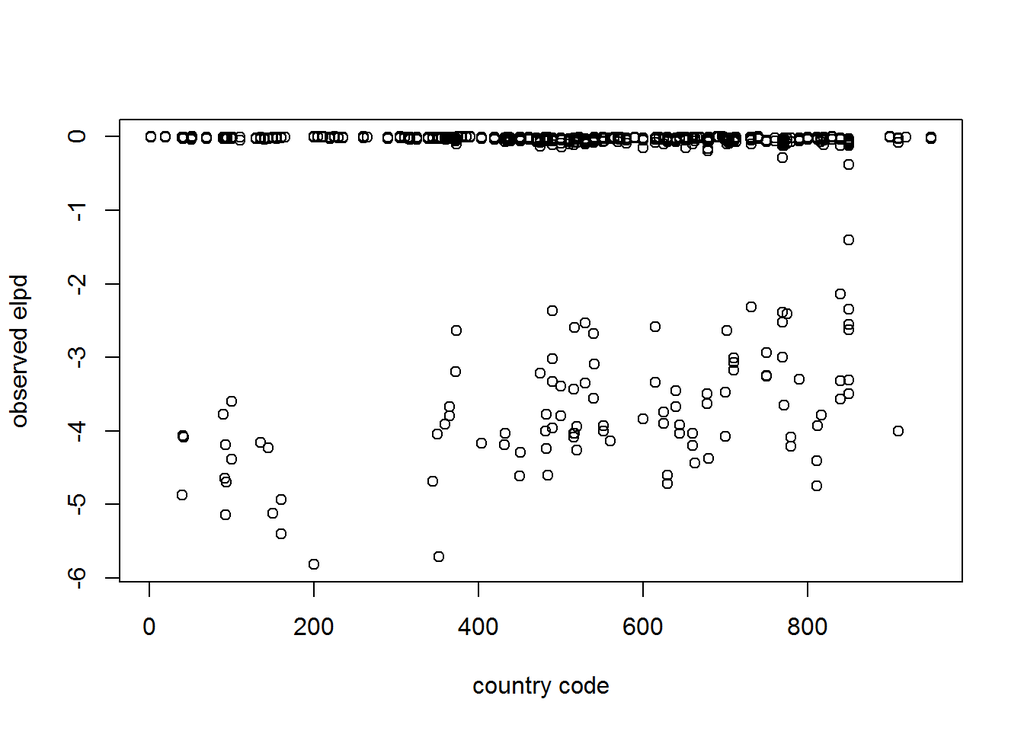

```r
# remove any rows with NaN
row.has.na <- apply(fl, 1, function(x){any(is.na(x))})
fl.filtered <- fl[!row.has.na,]

# extract elpd values and append to dataset
elpd <- as.data.frame(loo_mod4$pointwise)
fl.filtered$elpd_obs <- elpd$elpd_loo

# plot observed elpd values by country
plot(fl.filtered$ccode, fl.filtered$elpd_obs, ylab = "observed elpd", xlab = "country code")
```

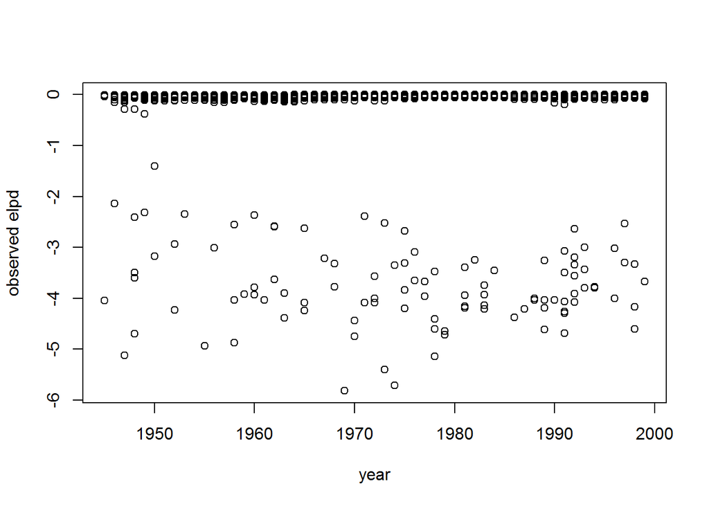

```r
# plot observed elpd values by year
plot(fl.filtered$year, fl.filtered$elpd_obs, ylab = "observed elpd", xlab = "year")
```

# Model size

## 4.1 Posterior predictive checks

I’m using the number of civil war onsets that occurred (actual and predicted) as the posterior predictive check statistic:

```r
# calculate the actual number of onsets in the dataset
obs_onset <- sum(fl$onset == 1)

# calculate posterior predictive with 500 draws from Models 3 and 4
pp.mod4 <- posterior_predict(mod4, draws = 500)

# count onsets in the posterior predictions for Models 3 and 4
onset.mod4 <- apply(pp.mod4, 1, function(x) sum(x==1))

# determine the mean difference in number of predicted onsets between the two models
cat("Mean difference in predicted vs. actual onsets:", mean(abs(onset.mod4 - obs_onset)))
```

```
## Mean difference in predicted vs. actual onsets: 11.912
```

```r
# determine the proportion of posterior predictive estimates that overestimate the number of onsets
cat("Proportion of predicted onsets that overestimate the actual number of onsets:", mean(onset.mod4 >= obs_onset))
```

```
## Proportion of predicted onsets that overestimate the actual number of onsets: 0.376
```

```r
# determine the proportion of posterior predictive estimates that underestimate the number of onsets
cat("Proportion of predicted onsets that underestimate the actual number of onsets:", mean(onset.mod4 <= obs_onset))
```

```
## Proportion of predicted onsets that underestimate the actual number of onsets: 0.646
```

# 5 Taking time seriously

I created variables of duration or time since onset (so present date - year date), as well as variables for the cubic polynomial (so duration^2 and duration^3).

```r
# remove any rows with NaN
row.has.na <- apply(fl, 1, function(x){any(is.na(x))})
fl.filtered <- fl[!row.has.na,]

# create variables of duration (time since onset)
fl.filtered$duration <- 2017 - fl.filtered$year
fl.filtered$duration2 <- fl.filtered$duration^2
fl.filtered$duration3 <- fl.filtered$duration^3
```

I ran a stan model including the variable duration in a cubic polynomial to estimate the parameter mu. I put regularizing priors on the polynomial coefficients (y_i, y_ii, y_iii). See the file ‘time.stan’ to check out what I tried with the stan model.

```r
# clean data table so only includes variables of interest
fl.d <- fl.filtered[ , 4:32]

# center variables
fl.d <- as.data.frame(scale(fl.d, center = TRUE, scale = FALSE))

# indicate the data that will be used in the model
 fl.mod6 <- list(N = nrow(fl.d),
           ons = fl.d$onset,
           K = ncol(fl.d),
           X = fl.d,
           d_i = fl.d$duration,
           d_ii = fl.d$duration2,
           d_iii = fl.d$duration3
           )

# fit a Bayesian model with hs priors on variable coefficients
# 2 chains and only 500 iterations so it runs faster
 fit.mod6 <- stan(file = 'time.stan',
               data = fl.mod6,
               chains = 2,
               iter = 500)
```

Show model summary (Rhat and Neff are very bad! Something must be wrong with my model):

```r
# show model summary
summary(fit.mod6, par = c("a", "y_i", "y_ii", "y_iii"))$summary
```

```
##             mean   se_mean        sd       2.5%        25%         50%
## a     -1.1431947 0.7616568 0.7624200 -1.9048523 -1.9048514 -1.14453135
## y_i   -0.0151533 1.8800263 1.8819095 -1.8952218 -1.8951693 -0.01785043
## y_ii   0.1889019 0.8878534 0.8889688 -0.7004923 -0.6983861  0.15190653
## y_iii  0.2727403 0.4234931 0.4240266 -0.1672397 -0.1549147  0.28706081
##              75%      97.5%    n_eff       Rhat
## a     -0.3813256 -0.3802244 1.002005 1471.48646
## y_i    1.8654476  1.8666359 1.002004 2630.62302
## y_ii   1.0952687  1.1119415 1.002514   65.28729
## y_iii  0.6962076  0.6962108 1.002521   87.05202
```

# 6 Time trends and time-varying coefficients

I’m a little confused about what this question is asking, and I also ran out of time trying to run these different models on my computer without crashing R :(